# Algorithm Beginner Class 3 Lecture

2018/6/2

# Array

## 1-D Array

1-D array represents mathematical vector.

1 byte: byte, boolean  
2 bytes: short, char  
4 bytes: int, float  
8 bytes: long, double

1. Create a 1D array

```java
int[] arr = new int[10];
```

**The length cannot be changed after creation.**

2. Get the size of the array

```java
package laioffer;
public class MyHelloWorld {
  public static void main(String[] args) {
    int n = 10;
    int[] arr = new int[n];
    System.out.println(arr.length);
  }
}
```

Note: `arr.length`, not `arr.length()`

3. Set an element

```java
arr[3] = 30;
```

4. Get an element

index –> value

```java
package laioffer;
public class MyHelloWorld {
  public static void main(String[] args) {
    int n = 10;
    int[] arr = new int[n];
    for (int i = 0; i < n; i = i + 1) {
      arr[i] = i * 10;
    }
    System.out.println(arr[5]);
  }
}
```

5. Define and initialize an array

```java
int[] arr1 = new int[4];
```

```java
int[] arr2 = {3,5,7,9};
```

```java
int[] arr3 = new int[]{3,5,7};
```

```java
package laioffer;
import java.util.*;
public class Test {
  public static void main(String[] args) {
    int[][] arr = {{2, 3, 5, 7}, {11, 13, 17, 19}};
    for (int[] a : arr) {
      for (int b : a) {
        System.out.println(b);
      }
    }
  }
}
```

## 2-D Array

2-D array represents mathematical matrix.

1. Create a 2D array

```java
int[][] mat1 = new int[4][6];
```

```java
int m = 4, n = 6;
int[][] matrix = new int[m][n];
```

You must specify the length of the matrix.

The length cannot be changed after creation.

2. Get the size of the 2D array

- row: `mat.length`
- column: `mat[0].length`

```java
package laioffer;
public class MyHelloWorld {
  public static void main(String[] args) {
    int m = 4, n = 6;
    int[][] matrix = new int[m][n];
    System.out.println("# of rows: " + matrix.length);
    System.out.println("# of columns: " + matrix[0].length);
  }
}
```

3. Set an element

```java
mat[3][2] = 30;
```

4. Get an element

```java
package laioffer;
public class MyHelloWorld {
  public static void main(String[] args) {
    int m = 4, n = 6;
    int[][] matrix = new int[m][n];
    for (int i = 0; i < m; i = i + 1) {
      for (int j = 0; j < n; j = j + 1) {
        matrix[i][j] = 10 *i + j;
      }
    }
    System.out.println(matrix[2][3]);
  }
}
```

5. Define and initialize an array

```java
int[][] mat1 = new int[3][4];
```

```java
int[][] mat2 = {{3, 2, 1}, {3, 4, 4}};
```

```java
int[][] mat3 = new int[][]{{3, 2, 1}, {3, 4, 4}};
```

# Main Function

Main function is the entry point of Java program; all other functions are directly or indirectly invoked by the main function.

`int[] array`  
`String[] strings`

```java
package laioffer;
public class Test {
  public static void main(String[] args) {
    System.out.println("Hello World!");
  }
}
```

## 1. Public

It means that you can call this method from outside of the class you are currently in. This is necessary because this method is being called by the Java runtime system which is not located in your current class.

## 2. Static

We will cover this later. For now, you can remember it as-is.

## 3. Void

The main() method must indeed have a void return type. Some thread invokes the exit method class System. In other words, the program may exit before or after the main method finishes; a return value from main would therefore be meaningless.

If you want the program to return a status code, call the following method:

```java
System.exit(int status);
```

```java
package laioffer;
public class Test {
  public static void main(String[] args) {
    System.out.println("Hi");
    //System.exit(1);
    System.out.println("Yo");
  }
}
```

## 4. Main

It’s just the name of method. This name is fixed and as it’s called by the JVM as entry point for an application.

The main function must have the name “main”, because there may be other “public static void xyz(String[] args)” function.

## 5. String arg[]

These are the arguments of type String that your Java application accepts when you run it. Normally we don’t use it for interviews.

```java
$ java MyApp arg1 arg2
$ java CountWord mydoc.txt yourdoc.txt
```

```java
package laioffer;
public class Test {
  public static void main(String[] args) {
    System.out.println(args.length);
    for (String s : args) {
      System.out.pint(s + " ");
    }
  }
}
```

1) Run –> Run Configurations…  
2) Arguments –> Program arguments: lai offer

Output:  
2  
lai  
offer

# The Object-Oriented Paradigm in Java

## Basic Concept

What is the thinking pattern? In Java:

Everything in the world is an object

- each object has a **type**
- each object is defined by two kinds of information
  - state: the “field”s - what things it maintains
  - behavior: the “method”s - what it can do

**class** - is like the basics for a house. Using these basic structures, you can build as many houses as you like. The “type” of the objects, example, each house should have doors, windows, beds… But usually in a class, you don’t know exactly how many.

**object** - each house you build (or instantiate, in OO lingo) is an **object**, also known as an **instance**. Each instance contains its own states, example, each of the ouse builts has its different number of doors, windows, beds…

**reference** - each house also has an address, of course. If you want to tell someone where the house is, you give them a card with the address written on it. That card is the object’s **reference**.

If you want to visit the house, you look at the address written on the card. This is called **dereferencing**.

Objects in real life: a list, a queue, an array, a program, a linked list node, etc.,…

## Working with Objects

The “new” keyword: create an object

```java
Student firstStudent = new Student("Tom");
```

```java
Student stu = new Student();
```

There are actually three important operations happened in this statement.

**Declaration**: associate a variable name with an object type.

*Student firstStudent;*  
Student –> the type of the object (can be a class, or an interface, or an enum… Let’s start with a class.)  
firstStudent –> variable name

**Instantiation (instance)**: The new keyword is a Java operator that creates the object.

*firstStudent = **new** Student(…);*  
Create an object in the memory and return its reference to firstStudent.

**Initialization**: The new operator is followed by a call to a constructor, which initializes the new object.

## Object memory layout

Memory spaces in a Java program: Stack and heap.

**Stack**: In computer science, a call stack is a stack data structure that stores information about the active subroutines of a computer program (stack frame). This kind of stack is also known as an execution stack, program stack, control stack, run-time stack, or machine stack, and is often shortened to just “the stack”.

**Heap**: Java objects reside in an area called the heap. The heap is created when the JVM starts up and may increase or decrease in size while the application runs.

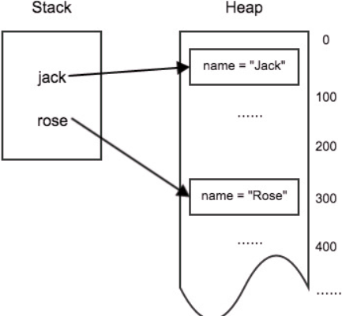

**Stack**: reference  
**Heap**: object

# Java “Hello World” 2: The more you should know

```java
public class Student {
  public int age;  //(member) field
  private final String name;  //(constant) field
  private static String school;  //(static) field
  private static final String GREETINGS = "Hello";  //(static constant) field

  public Student(String name) {  //Constructor
    this.name = name;  //name = n;
  }

  public int getAge() {  //(member) method, getter, accessor
    return age;
  }

  public void setAge(int age) {  (member) method, setter
    this.age = age;
  }

  public String getName() {  //(member) method, getter, accessor
    return name;
  }

  public void sayHello() {  //(member) method
    System.out.println(GREETINGS + "! I am " + name + ". I am " + age);
  }
}
public class HelloWorld {
  public static void main(String[] args) {
    Student firstStudent = new Student("Tom");

    Student secondStudent = new Student("Jerry");
    firstStudent = secondStudent;

    Student thirdStudent = null;
    firstStudent.setAge(18);
    secondStudent.setAge(10);
    firstStudent.sayHello();
    secondStudent.sayHello();
    Student thirdStudent = null;
    try {
      thirdStudent.sayHello();
    } catch (NullPointerException e) {
      System.out.println("Expected error occured! - " + e.toString());
    }
  }
}
```

## Constructor, this and Null pointers

Constructor: a special method to initialize objects, must have the **same name as the class**, **not return type**. By using constructors we can create objects with different parameters.

this: The current (self) instance. **Mandatory** if arguement name is the same as field name.

```java
public class Student {
  String name;
  void setName(String name) {
    this .name = name;  //Shadows a field
  }
}

s.setName("Tom");
```

null: An empty reference. Will cover in later classes.

## Static

Members (fields, methods, classes) **belong to class, not object**. [link](https://stackoverflow.com/questions/413898/what-does-the-static-keyword-do-in-a-class)